# Mobile Game Monetization Analysis

Argenis Cruz-Gonzalez

2025-11-26

# 1 Introduction

Free-to-play (F2P) mobile games rely on a small subset of paying users to drive most revenue. Understanding which player types spend, how much they spend, and what behaviors correlate with higher monetization is critical for designing effective product, marketing, and retention strategies.

This analysis examines an in-app purchase dataset from Kaggle (2025) to uncover how player demographics, gameplay behaviors, device type, and payment preferences relate to spending patterns. The goal is to translate raw data into insights that can inform monetization design, segmentation, and live-ops strategy.

# 2 Business Objective

How can a mobile game studio improve monetization by identifying which player and gameplay characteristics are most strongly associated with in-app purchase behavior?

This project answers that question by analyzing:

- Spending distribution across users
- Behavioral differences between Minnows, Dolphins, and Whales
- Relationships between engagement and revenue
- Device-level and genre-level monetization differences
- Payment method performance and user preferences

# 3 Problems

To support monetization strategy, mobile gaming studios need clarity on several questions:

- Unknown spending distribution — How much revenue comes from top vs. average players?
- Whale dependency — To what extent is revenue concentrated among a small minority?
- Engagement–spending disconnect — Does more playtime actually correlate with higher spending?
- Genre, device, and payment differences — Which player attributes predict stronger monetization?
- Data noise — Missing values, zero-spend users, and inconsistent device labels require cleaning.

# 4 Dataset Source

Dataset Source: Kaggle – Mobile Game In-App Purchases Dataset (2025)  
Contains 3,024 rows × 13 columns covering demographics, behavior, and purchase patterns.

# 5 Load & Clean Data

```r
library(tidyverse)
library(ggplot2)
library(reshape2)
library(corrplot)

# Load dataset
f2p_purchases <- read_csv("mobile_game_inapp_purchases.csv")

# Clean Spending Segment
f2p_purchases$SpendingSegment <- factor(
  f2p_purchases$SpendingSegment,
  levels = c("Minnow", "Dolphin", "Whale")
)

# Clean Device (safe version)
f2p_purchases$Device <- f2p_purchases$Device |>
  trimws() |>
  na_if("") |>
  forcats::fct_explicit_na("NA") |>
  factor(levels = c("Android", "iOS", "NA"))

# REMOVE ZERO-SPEND ROW
f2p_purchases <- f2p_purchases %>%
  filter(InAppPurchaseAmount > 0)
```

# 6 Analysis

## 6.1 Engagement vs Spending Visualization

### 6.1.1 Relationship Between Session Count and Purchase Amount (Fixed Scale)

Using a fixed y-axis scale allows direct visual comparison across all three spending segments. The chart shows that whales consistently spend far more than minnows and dolphins regardless of session count, and their spending values dominate the shared scale. This reinforces the fact that spending behavior varies dramatically between segments, with whales contributing disproportionately to revenue even at lower engagement levels. The fixed scale highlights how wide the gap is between these groups.

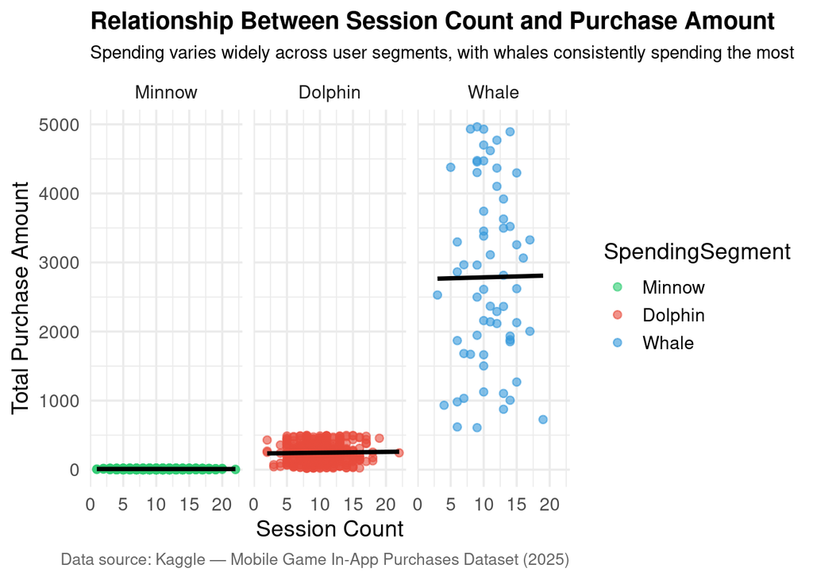

```r
ggplot(f2p_purchases, aes(x = SessionCount,
                          y = InAppPurchaseAmount,
                          color = SpendingSegment)) +
  geom_point(alpha = 0.6) +
  geom_smooth(method = "lm", se = FALSE, color = "black") +
  facet_wrap(~ SpendingSegment, scales = "fixed") +
  scale_color_manual(values = c(
    "Minnow" = "#2ecc71",
    "Dolphin" = "#e74c3c",
    "Whale"  = "#3498db"
  )) +
  labs(
    title = "Relationship Between Session Count and Purchase Amount",
    subtitle = "Spending varies widely across user segments, with whales consistently spending the most",
    x = "Session Count",
    y = "Total Purchase Amount",
    caption = "Data source: Kaggle — Mobile Game In-App Purchases Dataset (2025)"
  )
```

### 6.1.2 Relationship Between Session Count and Purchase Amount (Free Y-Axis)

The free y-axis version makes it easier to see patterns within each individual segment. For minnows and dolphins, spending remains relatively low and shows only mild variation across session counts. For whales, the increased vertical resolution reveals that their spending is highly variable and not strongly tied to session volume. This view emphasizes within-segment behavior: engagement does not predict spending even among whales, suggesting monetization psychology and game design factors play a larger role than raw playtime.

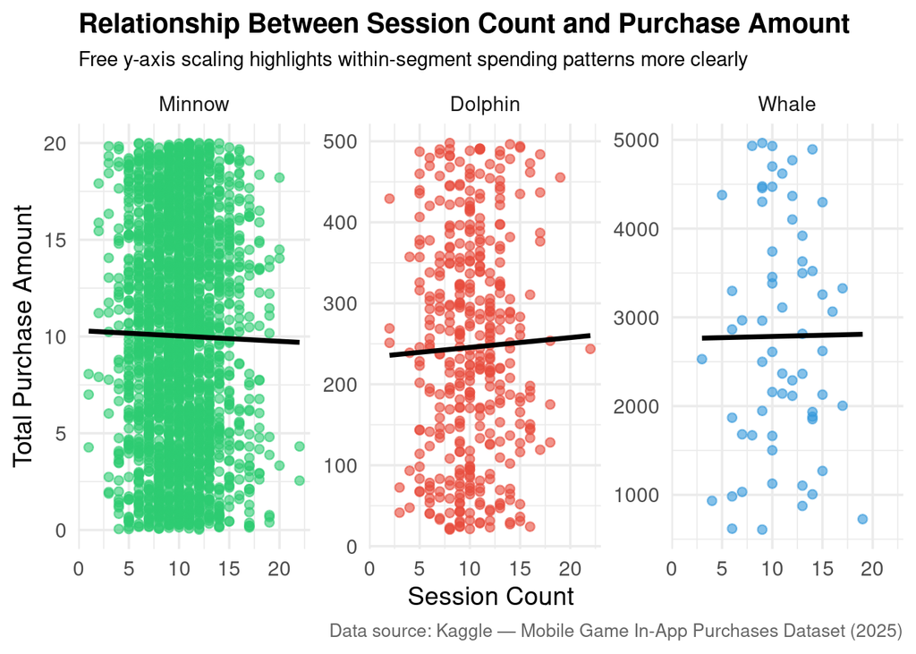

```r
ggplot(f2p_purchases, aes(x = SessionCount,
                          y = InAppPurchaseAmount,
                          color = SpendingSegment)) +
  geom_point(alpha = 0.6) +
  geom_smooth(method = "lm", se = FALSE, color = "black") +
  facet_wrap(~ SpendingSegment, scales = "free_y") +
  scale_color_manual(values = c(
    "Minnow" = "#2ecc71",
    "Dolphin" = "#e74c3c",
    "Whale"  = "#3498db"
  )) +
  labs(
    title = "Relationship Between Session Count and Purchase Amount",
    subtitle = "Free y-axis scaling highlights within-segment spending patterns more clearly",
    x = "Session Count",
    y = "Total Purchase Amount",
    caption = "Data source: Kaggle — Mobile Game In-App Purchases Dataset (2025)"
  ) +
  theme(
    legend.position = "none"
  )
```

## 6.2 Pareto Curve (Revenue Concentration)

The Pareto curve reveals a highly concentrated monetization pattern, where a very small fraction of players generates the vast majority of revenue. The steep rise at the beginning of the curve shows that top spenders, whales, contribute disproportionately, with the top 1–10% of paying users accounting for most in-app purchase revenue. This indicates a heavy reliance on high-value players, a common characteristic of free-to-play economies. Such concentration creates both an opportunity and a risk: retaining whales can significantly boost revenue, but losing even a few may cause noticeable financial impact.

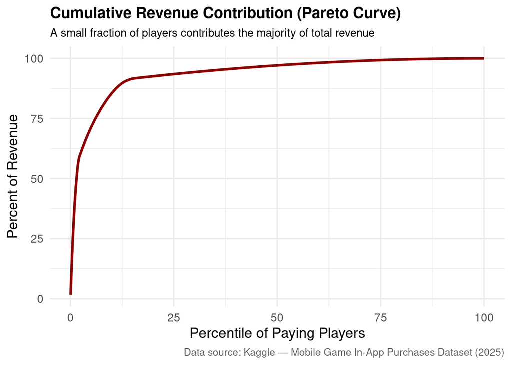

```r
df_rev <- f2p_purchases %>%
  filter(InAppPurchaseAmount > 0) %>%
  arrange(desc(InAppPurchaseAmount)) %>%
  mutate(
    cum_rev = cumsum(InAppPurchaseAmount),
    perc_rev = cum_rev / sum(InAppPurchaseAmount) * 100,
    player_rank = row_number(),
    perc_players = player_rank / n() * 100
  )

ggplot(df_rev, aes(x = perc_players, y = perc_rev)) +
  geom_line(color = "darkred", size = 1.2) +
  labs(
    title = "Cumulative Revenue Contribution (Pareto Curve)",
    subtitle = "A small fraction of players contributes the majority of total revenue",
    x = "Percentile of Paying Players",
    y = "Percent of Revenue",
    caption = "Data source: Kaggle — Mobile Game In-App Purchases Dataset (2025)"
  )
```

## 6.3 ARPPU Chart

### 6.3.1 ARPPU by Session Group

The ARPPU chart shows that spending peaks in the 11–20 session group, suggesting that moderately engaged players tend to spend the most. However, ARPPU drops in the 21–40 session range, and the large error bar reveals extremely high variability within this bucket.

Initially, it appeared that this instability was being caused by whales—since whales are usually the players responsible for extreme outliers in spending. The pattern seemed to support a common industry assumption: highly engaged players tend to include both high-value whales and low-value minnows, producing a wide spread.

But the raw ARPPU view alone can be misleading, as it conflates all payer types together.

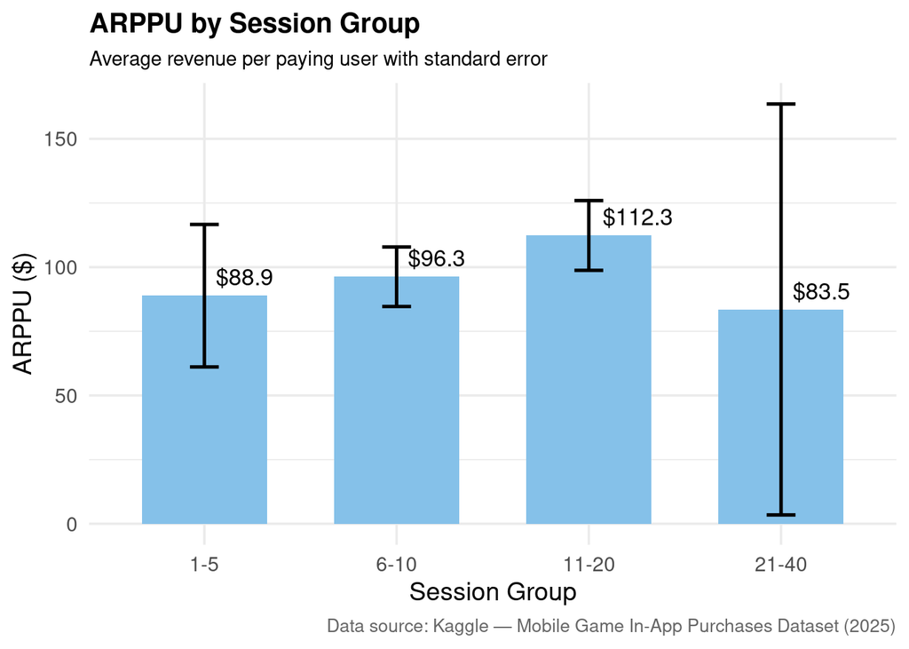

```r
# Calculate ARPPU
arppu <- f2p_purchases %>%
  filter(InAppPurchaseAmount > 0) %>%
  mutate(
    session_group = case_when(
      SessionCount <= 5 ~ "1-5",
      SessionCount <= 10 ~ "6-10",
      SessionCount <= 20 ~ "11-20",
      SessionCount <= 40 ~ "21-40",
      TRUE ~ "40+"
    ),
    # FIX: enforce numeric display order
    session_group = factor(session_group,
                           levels = c("1-5", "6-10", "11-20", "21-40", "40+"))
  ) %>%
  group_by(session_group) %>%
  summarise(
    arppu = mean(InAppPurchaseAmount),
    se = sd(InAppPurchaseAmount) / sqrt(n())
  )

ggplot(arppu, aes(x = session_group, y = arppu)) +
  geom_col(fill = "#85C1E9", width = 0.65) +
  geom_errorbar(aes(ymin = arppu - se, ymax = arppu + se),
                width = 0.15, color = "black", size = 0.9) +
  geom_text(aes(label = paste0("$", round(arppu, 1))),
            hjust = -0.2, vjust = -0.6, size = 4.5) +
  coord_cartesian(clip = "off") +
  labs(
    title = "ARPPU by Session Group",
    subtitle = "Average revenue per paying user with standard error",
    x = "Session Group",
    y = "ARPPU ($)",
    caption = "Data source: Kaggle — Mobile Game In-App Purchases Dataset (2025)"
  )
```

### 6.3.2 ARPPU by Session Group, Faceted by Spending Segment

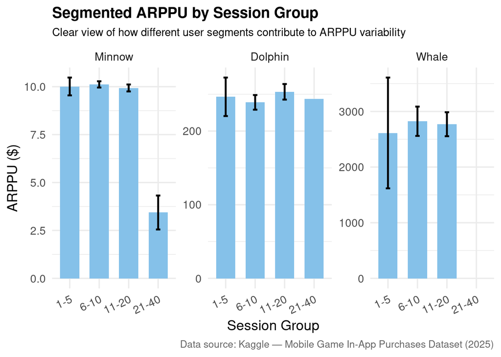

```r
# Faceted ARPPU calculation
arppu_segmented <- f2p_purchases %>%
  filter(InAppPurchaseAmount > 0) %>%
  mutate(
    session_group = case_when(
      SessionCount <= 5 ~ "1-5",
      SessionCount <= 10 ~ "6-10",
      SessionCount <= 20 ~ "11-20",
      SessionCount <= 40 ~ "21-40",
      TRUE ~ "40+"
    ),
    session_group = factor(session_group,
                           levels = c("1-5", "6-10", "11-20", "21-40", "40+"))
  ) %>%
  group_by(SpendingSegment, session_group) %>%
  summarise(
    arppu = mean(InAppPurchaseAmount),
    se = sd(InAppPurchaseAmount) / sqrt(n()),
    .groups = "drop"
  )

ggplot(arppu_segmented, aes(x = session_group, y = arppu)) +
  geom_col(fill = "#85C1E9", width = 0.65) +
  geom_errorbar(aes(ymin = arppu - se, ymax = arppu + se),
                width = 0.15, color = "black", size = 0.9) +
  facet_wrap(~SpendingSegment, scales = "free_y") +
  labs(
    title = "Segmented ARPPU by Session Group",
    subtitle = "Clear view of how different user segments contribute to ARPPU variability",
    x = "Session Group",
    y = "ARPPU ($)",
    caption = "Data source: Kaggle — Mobile Game In-App Purchases Dataset (2025)"
  ) +
  theme(
    axis.text.x = element_text(angle = 25, hjust = 1),
  )
```

## 6.4 Correlation Matrix

The correlation matrix shows that none of the gameplay or demographic variables strongly predict in-app purchase spending. Key engagement metrics—such as session count, average session length, and first purchase timing—display correlations close to zero with total spending. This reinforces a recurring pattern in free-to-play games: monetization behavior is not driven by raw engagement but by psychological, motivational, and segment-specific factors. The weak correlations support earlier findings that whales behave fundamentally differently from the rest of the player base, making spending difficult to explain using simple gameplay metrics.

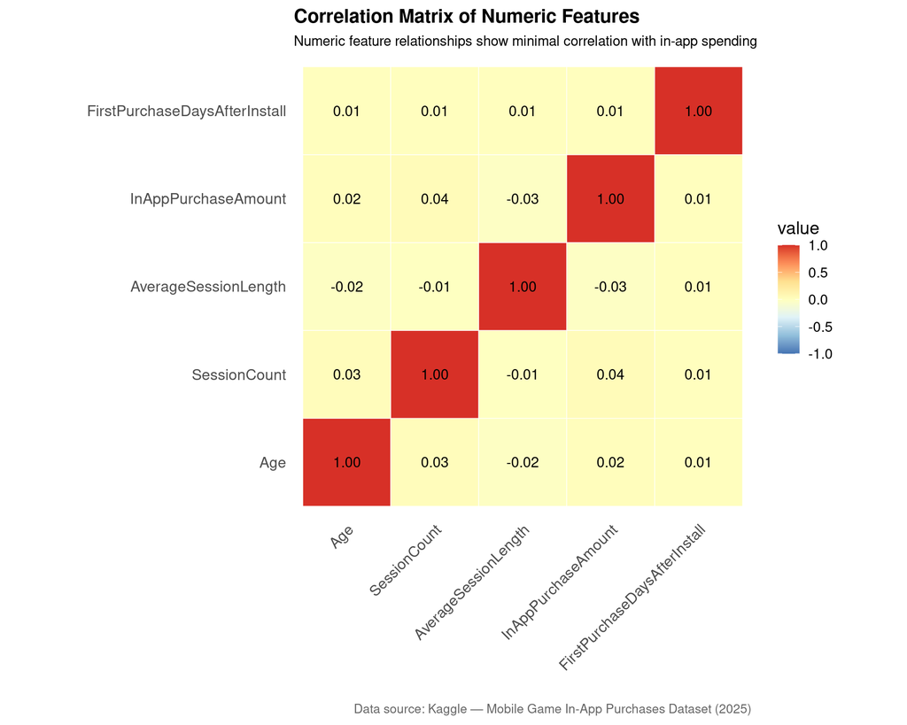

```r
numeric_df <- f2p_purchases[sapply(f2p_purchases, is.numeric)]
cor_matrix <- round(cor(numeric_df, use = "pairwise.complete.obs"), 2)
melted <- melt(cor_matrix)

ggplot(melted, aes(x = Var1, y = Var2, fill = value)) +
  geom_tile(color = "white") +
  geom_text(aes(label = sprintf("%.02f", value)), size = 4) +
  scale_fill_distiller(palette = "RdYlBu", direction = -1, limits = c(-1, 1)) +
  coord_fixed() +
  labs(
    title = "Correlation Matrix of Numeric Features",
    subtitle = "Numeric feature relationships show minimal correlation with in-app spending",
    caption = "Data source: Kaggle — Mobile Game In-App Purchases Dataset (2025)",
    x = "",
    y = ""
  ) +
  theme(
    axis.text.x = element_text(angle = 45, hjust = 1, size = 12),
    axis.text.y = element_text(size = 12),
    panel.grid = element_blank()
  )
```

## 6.5 Genre-Based Monetization

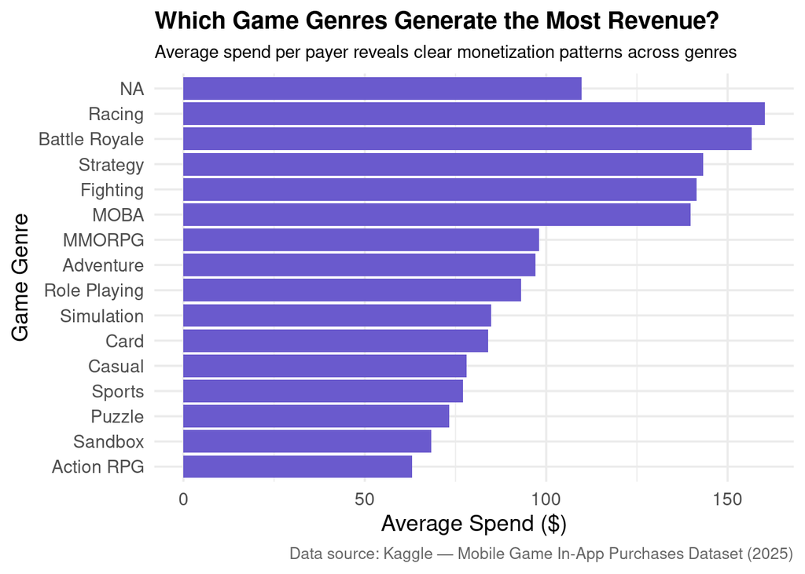

```r
genre_spend <- f2p_purchases %>%
  filter(InAppPurchaseAmount > 0) %>%
  group_by(GameGenre) %>%
  summarise(
    avg_spend = mean(InAppPurchaseAmount),
    median_spend = median(InAppPurchaseAmount),
    whale_rate = mean(SpendingSegment == "Whale") * 100,
    count = n()
  ) %>%
  arrange(desc(avg_spend))

ggplot(genre_spend, aes(x = reorder(GameGenre, avg_spend), y = avg_spend)) +
  geom_col(fill = "#6A5ACD") +
  coord_flip() +
  labs(
    title = "Which Game Genres Generate the Most Revenue?",
    subtitle = "Average spend per payer reveals clear monetization patterns across genres",
    x = "Game Genre",
    y = "Average Spend ($)",
    caption = "Data source: Kaggle — Mobile Game In-App Purchases Dataset (2025)"
  )
```

## 6.6 Device Monetization

The device comparison shows that iOS players spend noticeably more on average than Android players. This aligns with long-standing industry trends: iOS users tend to have higher purchasing power and are more likely to engage in discretionary spending within apps. Although Android represents a larger global user base, its average payer value is often lower due to broader demographic reach and more price-sensitive segments. Overall, device type appears to be a meaningful predictor of monetization potential, suggesting that platform-specific acquisition and retention strategies could improve revenue outcomes.

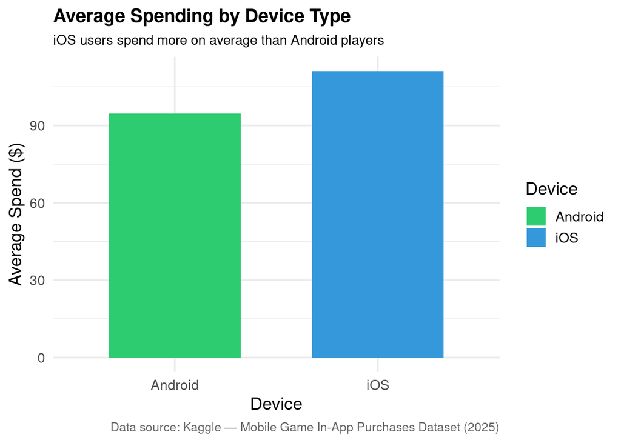

```r
device_spend <- f2p_purchases %>%
  filter(Device != "NA") %>%
  group_by(Device) %>%
  summarise(
    avg_spend = mean(InAppPurchaseAmount),
    median_spend = median(InAppPurchaseAmount),
    payer_rate = mean(InAppPurchaseAmount > 0) * 100,
    whale_rate = mean(SpendingSegment == "Whale") * 100,
    count = n()
  ) %>%
  arrange(desc(avg_spend))

## Visualization
ggplot(device_spend, aes(x = Device, y = avg_spend, fill = Device)) +
  geom_col(width = 0.65) +
  scale_fill_manual(values = c("iOS" = "#3498db", "Android" = "#2ecc71")) +
  labs(
    title = "Average Spending by Device Type",
    subtitle = "iOS users spend more on average than Android players",
    x = "Device",
    y = "Average Spend ($)",
    caption = "Data source: Kaggle — Mobile Game In-App Purchases Dataset (2025)"
  )
```

## 6.7 Payment Method Monetization

The payment method breakdown shows clear differences in average spending based on how users choose to pay. Debit Card and PayPal users exhibit the highest average spend, suggesting these methods are preferred by more committed or higher-value players. Gift Cards and Carrier Billing also show moderate spending, but mobile wallet users—such as Apple Pay and Google Pay—tend to spend less in this dataset. While this pattern differs from some broader industry expectations, it likely reflects demographic differences or sample-specific behaviors. Overall, payment method appears to be a meaningful indicator of spending intensity, offering opportunities to optimize checkout flows or tailor promotions around high-value methods.

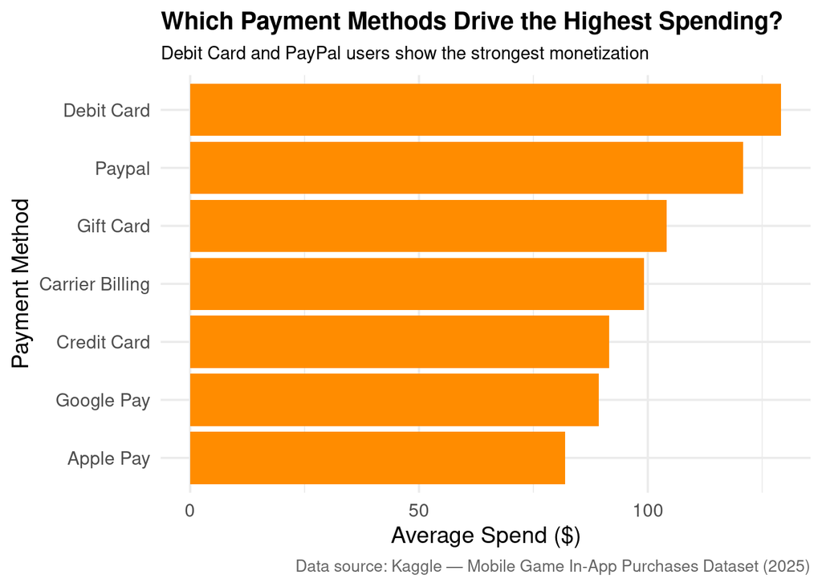

```r
payment_spend <- f2p_purchases %>%
  group_by(PaymentMethod) %>%
  summarise(
    avg_spend = mean(InAppPurchaseAmount),
    median_spend = median(InAppPurchaseAmount),
    whale_rate = mean(SpendingSegment == "Whale") * 100,
    count = n()
  )

ggplot(payment_spend, aes(x = reorder(PaymentMethod, avg_spend),
                          y = avg_spend)) +
  geom_col(fill = "#FF8C00") +
  coord_flip() +
  labs(
    title = "Which Payment Methods Drive the Highest Spending?",
    subtitle = "Debit Card and PayPal users show the strongest monetization",
    x = "Payment Method",
    y = "Average Spend ($)",
    caption = "Data source: Kaggle — Mobile Game In-App Purchases Dataset (2025)"
  )
```

# 7 Recommendations

Based on the full analysis, several actionable insights emerge for a game studio:

## 7.1 Strengthen Dolphin-Level Monetization

- Introduce mid-tier bundles, progression boosters, and time-limited upgrades
- Provide targeted offers when Dolphins approach key grind points
- Personalize messaging to convert “aspiring whales” more consistently

## 7.2 Improve Early Engagement Funnels

ARPPU peaks around 11–20 sessions, indicating a critical window:

- Add onboarding offers, first-purchase bonuses, and soft-currency multipliers
- Reduce friction in early progression to accelerate players into the “sweet spot”

## 7.3 Prioritize iOS for High-Value User Acquisition

- Shift marketing budgets toward iOS channels
- Launch feature tests (events, offers, bundles) on iOS first
- Tailor push notifications and retention incentives by device

## 7.4 Optimize Payment Flows for High-Value Methods

Debit card and PayPal drive the highest spend:

- Surface these options earlier and more prominently
- Reduce steps in checkout for these payment methods
- Test targeted incentives (“Save 10% on your next purchase with PayPal”)

## 7.5 Invest in Competitive & Progression-Driven Genres

- Prioritize new features, modes, or live-ops focused on competitive engagement
- Explore in-game economies that reinforce progression loops
- Expand content depth for these genres (ranked systems, events, cosmetic tiers)

## 7.6 Manage Whale Risk Through Retention Design

The Pareto curve shows extreme revenue concentration:

- Implement VIP systems, loyalty rewards, exclusive skins, and early-access events
- Add high-price cosmetic bundles to protect revenue per whale
- Monitor churn signals (playtime dips, missed events) closely

# 8 Conclusion

Genre, device type, and payment method further reveal that monetization is shaped by who players are, how they play, and how they choose to pay — not simply by how often they log in.

By combining behavioral segmentation with targeted monetization design, the studio can:

- Strengthen mid-tier spending
- Improve early-funnel conversion
- Reduce whale-dependency risk
- Optimize acquisition and payment strategies
- Build a more resilient, predictable revenue model

This project demonstrates how data can illuminate player motivations and guide monetization strategy, providing a foundation for more advanced modeling such as churn prediction, LTV forecasting, and segment-specific offer optimization.